# Inferential Data Analysis

Charles

August 7, 2017

## Overview

In this report we’ll analyze the ToothGrowth data in the R datasets package and have a basic Inferential Data Analysis.

## Basic exploratory data analysis

Firstly we set up the environment:

```r
setwd("C:/Study/Coursera/1 Data-Science/2 RStudio/6 Class 6/Coursera_DataScience_Class6_FinalProject")
set.seed(135246987)
library(ggplot2)
library(gridExtra)
library(grid)
library(datasets)
```

Then we load the data and summarize the data:

```r
data("ToothGrowth")
dataTG <- ToothGrowth
str(dataTG)
```

```
## 'data.frame':    60 obs. of  3 variables:
##  $ len : num  4.2 11.5 7.3 5.8 6.4 10 11.2 11.2 5.2 7 ...
##  $ supp: Factor w/ 2 levels "OJ","VC": 2 2 2 2 2 2 2 2 2 2 ...
##  $ dose: num  0.5 0.5 0.5 0.5 0.5 0.5 0.5 0.5 0.5 0.5 ...
```

```r
head(dataTG)
```

```
##    len supp dose
## 1  4.2   VC  0.5
## 2 11.5   VC  0.5
## 3  7.3   VC  0.5
## 4  5.8   VC  0.5
## 5  6.4   VC  0.5
## 6 10.0   VC  0.5
```

```r
summary(dataTG)
```

```
##       len        supp         dose
##  Min.   : 4.20   OJ:30   Min.   :0.500
##  1st Qu.:13.07   VC:30   1st Qu.:0.500
##  Median :19.25           Median :1.000
##  Mean   :18.81           Mean   :1.167
##  3rd Qu.:25.27           3rd Qu.:2.000
##  Max.   :33.90           Max.   :2.000
```

```r
dataTG$dose <- as.factor(dataTG$dose)
```

We can get a general idea of the data according to explore above. Then we can do some exploratory data analysis by drawing relationships between length and supp & dose.

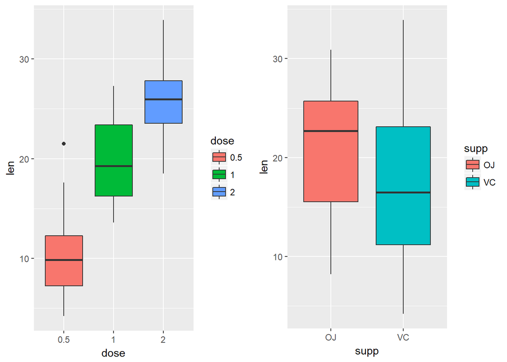

```r
g1 <- ggplot(data = dataTG, aes(x=dose, y=len)) +
        geom_boxplot(aes(fill = dose))
g2 <- ggplot(data = dataTG, aes(x=supp ,y=len)) +
        geom_boxplot(aes(fill = supp))
grid.arrange(g1,g2,nrow=1)
```

As we can see above, it seems the length grows as dose increases. While the replationship between length and supp is not quite obvious.

## T test for length and supp

We conduct t-test for length and supp:

```r
t.test(len ~ supp, data = dataTG, alternative ="two.sided")
```

```
##
##  Welch Two Sample t-test
##
## data:  len by supp
## t = 1.9153, df = 55.309, p-value = 0.06063
## alternative hypothesis: true difference in means is not equal to 0
## 95 percent confidence interval:
##  -0.1710156  7.5710156
## sample estimates:
## mean in group OJ mean in group VC
##         20.66333         16.96333
```

As we can see above, $95 \%$ confidence interval contains zero and p-value is about 0.06. So we wouldn’t reject the null hypothesis, which means true difference in means is equal to 0.

## T test for length and dose.

We divide the data into three groups: dose in 0.5 and 1; dose in 0.5 and 2; dose in 1 and 2.

```r
dataTG_0.5_1.0 <- subset(dataTG, dose %in% c("0.5","1"))
dataTG_0.5_2.0 <- subset(dataTG, dose %in% c("0.5","2"))
dataTG_1.0_2.0 <- subset(dataTG, dose %in% c("1","2"))
```

Then do the t-test:

```r
t.test(len ~ dose, data = dataTG_0.5_1.0)
```

```
##
##  Welch Two Sample t-test
##
## data:  len by dose
## t = -6.4766, df = 37.986, p-value = 1.268e-07
## alternative hypothesis: true difference in means is not equal to 0
## 95 percent confidence interval:
##  -11.983781  -6.276219
## sample estimates:
## mean in group 0.5   mean in group 1
##            10.605            19.735
```

```r
t.test(len ~ dose, data = dataTG_0.5_2.0)
```

```
##
##  Welch Two Sample t-test
##
## data:  len by dose
## t = -11.799, df = 36.883, p-value = 4.398e-14
## alternative hypothesis: true difference in means is not equal to 0
## 95 percent confidence interval:
##  -18.15617 -12.83383
## sample estimates:
## mean in group 0.5   mean in group 2
##            10.605            26.100
```

```r
t.test(len ~ dose, data = dataTG_1.0_2.0)
```

```
##
##  Welch Two Sample t-test
##
## data:  len by dose
## t = -4.9005, df = 37.101, p-value = 1.906e-05
## alternative hypothesis: true difference in means is not equal to 0
## 95 percent confidence interval:
##  -8.996481 -3.733519
## sample estimates:
## mean in group 1 mean in group 2
##          19.735          26.100
```

As we can see above, all three test the p-value is smaller than $5\%$ and the $95 \%$ confidence interval dose not contain zero. Besides, they are all negative, which means there’s an increase as dose goes up.

## Conclusions and assumptions

According to the analysis above, we could see that under $95 \%$ confidence interval:

- Supplement has no effect on the length of tooth growth.
- Tooth grows longer as the dose increases.

Assumptions:

- The experiment was properly conducted.
- The sample data is good enough to represent the entire population.